# Constructing identity analysis

Colin Tredoux

THis document records some work complementing that carried out by Foud and VIAPPL team - constructing identity document.

# Preliminaries

Load some libraries

```
Skipping install of 'slipper' from a github remote, the SHA1 (bd395641) has not changed since last install.
  Use `force = TRUE` to force installation
```

# Load the data

[output not shown]

Total cases matches that set down by Fouad in the document.

We need to identify the variables, we do this from the file “Apr17 untrimmed output inequality.txt” which we find in the Dropbox. This tells us the vars for the unequal groups data file.

This tells us that the clustering structure used was gameno, with grouping factor = condition.

The variables we need are IGF, OGG (OA in the article), rich (status, I think), gameno, ID (pre-id), pID (post-id), deltatokens (I assume the diff between beginning and end of game).

Let’s try and construct Fig 1 in the MS

# Fig 1

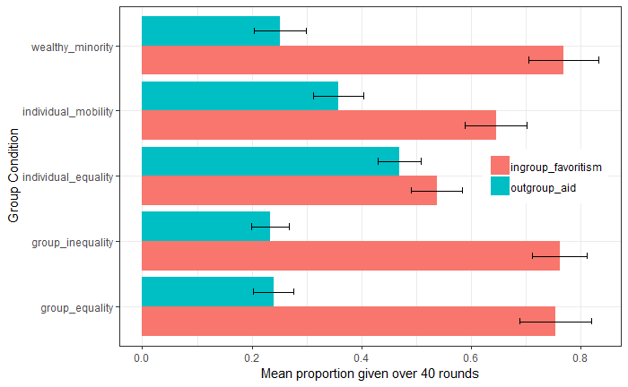

```r
mns <- id_all.dat %>%
    select(group_condition, ingroup_favoritism:outgroup_aid) %>%
    gather(key = dv, value = amt_given, ingroup_favoritism:outgroup_aid) %>%
    group_by(group_condition, dv) %>%
    summarise(mean=mean(amt_given),
              sd = sd(amt_given),
              n = n(),
              ci = (sd/sqrt(n))*1.96)
ggplot(mns, aes(x = group_condition, y = mean, fill = dv))  +
    geom_bar(position=position_dodge(), stat="identity") +
    geom_errorbar(aes(ymin=mean-ci, ymax=mean+ci),
                  width=.2,                    # Width of the error bars
                  position=position_dodge(.9)) +
    coord_flip() +
    theme_bw() +
    labs(x = "Group Condition", y = "Mean proportion given over 40 rounds") +
    theme(legend.title = element_blank(),
          legend.position = c(0.85,0.5))
ggsave("Figure_group_by_giving.pdf")
```

OK, lets try Figure 2 now

# Fig 2

```r
# Build dataframe that contains standard deviations for conditions
# on Token change and let's bootstrap that a few times to get CIs


id_all.dat %>%
    group_by(group_condition) %>%
    summarise(sd = sd(delta_tokens, na.rm = T)/10)

id_all.dat %>%
    select(group_condition, delta_tokens, uid) %>%
    spread(key = group_condition, value = delta_tokens) %>%
    select(-uid) -> x

x %>% summarise_all(funs(sd),na.rm = T)  -> z


x %>% slipper_ci(sd(group_equality, na.rm = T),B=1000) -> group_equality
x %>% slipper_ci(sd(group_inequality, na.rm = T),B=1000) -> group_inequality
x %>% slipper_ci(sd(individual_equality, na.rm = T),B=1000) -> individual_equality
x %>% slipper_ci(sd(individual_mobility, na.rm = T),B=1000) -> individual_mobility
x %>% slipper_ci(sd(wealthy_minority, na.rm = T),B=1000) -> wealthy_minority
group_boot_cis <- full_join(group_equality, group_inequality) %>%
    full_join(individual_equality) %>% full_join(individual_mobility) %>%
    full_join(wealthy_minority)

group_boot_cis$group_condition <- c("group_equality", "group_inequality",
                                    "individual_equality", "individual_mobility",
                                    "wealthy_minority")
group_boot_cis$Standard_deviation <- t(z)

rm(x, group_equality, group_inequality, individual_equality, individual_mobility,
   wealthy_minority, z)

ggplot(group_boot_cis, aes(x = reorder(group_condition, Standard_deviation),
                                       y = Standard_deviation))  +
    geom_bar(position=position_dodge(), stat="identity", color="red",
             fill = "light grey") +
    geom_errorbar(aes(ymin=ci_low, ymax=ci_high),
                  width=.2,                    # Width of the error bars
                  position=position_dodge(.9)) +
    # coord_flip() +
    theme_bw() +
    labs(x = "",
         y = "Standard deviation of token change over 40 rounds",
         caption = "I bars are bootstrap confidence intervals (1000 samples")
ggsave("Figure_group_by_sd_token.pdf")
```

[output not shown]

Now let’s test the sds to see if they differ. We try the Fligner-Killeen test # Test SDs

```r
id_all.dat$group_condition <- factor(id_all.dat$group_condition)
fligner.test(delta_tokens ~ group_condition, data=id_all.dat)

(data=id_all.dat %>% filter(group_condition == "group_equality" |
                            group_condition == "group_inequality") %$%
                            fligner.test(delta_tokens ~ group_condition))
(data=id_all.dat %>% filter(group_condition == "group_equality" |
                            group_condition == "individual_equality") %$%
                            fligner.test(delta_tokens ~ group_condition))
(data=id_all.dat %>% filter(group_condition == "group_equality" |
                            group_condition == "individual_mobility") %$%
                            fligner.test(delta_tokens ~ group_condition))
(data=id_all.dat %>% filter(group_condition == "group_equality" |
                            group_condition == "wealthy_minority") %$%
                            fligner.test(delta_tokens ~ group_condition))
(data=id_all.dat %>% filter(group_condition == "group_inequality" |
                            group_condition == "individual_equality") %$%
                            fligner.test(delta_tokens ~ group_condition))
(data=id_all.dat %>% filter(group_condition == "group_inequality" |
                            group_condition == "individual_mobility") %$%
                            fligner.test(delta_tokens ~ group_condition))
(data=id_all.dat %>% filter(group_condition == "group_inequality" |
                            group_condition == "wealthy_minority") %$%
                            fligner.test(delta_tokens ~ group_condition))
(data=id_all.dat %>% filter(group_condition == "individual_equality" |
                            group_condition == "individual_mobility") %$%
                            fligner.test(delta_tokens ~ group_condition))
(data=id_all.dat %>% filter(group_condition == "individual_equality" |
                            group_condition == "wealthy_minority") %$%
                            fligner.test(delta_tokens ~ group_condition))
(data=id_all.dat %>% filter(group_condition == "individual_mobility" |
                            group_condition == "wealthy_minority") %$%
                            fligner.test(delta_tokens ~ group_condition))
```

We need to check reliability of id measures # Reliability analysis

```r
id_all.dat %>%
    select(id1:id3) %>%
    omega(nfactors=1)

id_all.dat %>%
    select(p_id1:p_id3) %>%
    omega(nfactors=1)

id_all.dat %>%
    select(id1:id3) %>%
    summary()
```

Can try the Mixed models test on change in social id over time

# Does social id change over time?

```r
id_all.dat %>%
    select(uid, id, p_id, group_condition, gameno) %>%
    gather(key = time, value = socid, id:p_id) %>%
    mutate(uid = factor(uid)) -> id_all_lme.dat


a <- lme(socid ~ 1, random = ~1|uid,
                 data = id_all_lme.dat,
                 na.action = na.omit)

b <- lme(socid ~ time, random = ~1|uid,
                 data = id_all_lme.dat,
                 na.action = na.omit)

c <- lme(socid ~ time, random = ~1|gameno/uid,
                 data = id_all_lme.dat,
                 na.action = na.omit)

d <- lme(socid ~ time*group_condition, random = ~1|uid,
                data = id_all_lme.dat,
                na.action = na.omit,
                method="ML")

# Re-do model in order to do posthocs
library(lme4)
d <- lmer(socid ~ time*group_condition + (1|uid),
                data = id_all_lme.dat,
                na.action = na.omit)
d <- lmerTest::lmer(socid ~ time*group_condition + (1|uid),
                data = id_all_lme.dat,
                na.action = na.omit)
summary(d)
anova(d)
# Look at posthoc tests
library(lsmeans)
# lsmeans(model2way, ~group_space|community)
# contrast(model2way, method = "eff")
lsmeans(d, ~time|group_condition)
lsmeans(d, list(pairwise ~ time|group_condition), adjust = "tukey")
```

```r
id_all_lme.dat %>%
    group_by(group_condition, time) %>%
    summarise(mean_socid = mean(socid, na.rm = T),
              sd = sd(socid, na.rm = T),
              n= n(),
              ci = (sd/sqrt(n))*1.96) -> id_all_lme_mns.dat

ggplot(id_all_lme_mns.dat, aes(x = group_condition, y = mean_socid, fill = time)) +
    geom_bar(position=position_dodge(), stat="identity") +
    geom_errorbar(aes(ymin=mean_socid-ci, ymax=mean_socid+ci),
                  width=.2,                    # Width of the error bars
                  position=position_dodge(.9)) +
    theme_bw() +
    labs(x = "Group Condition", y = "Social Identification") +
    theme(legend.title = element_blank(),
          legend.position = c(0.80,0.90))
ggsave("Figure_group_by_socid_time.pdf")
```

[output not shown]

Let’s turn to the SEM models

# SEM models

```r
resid(socid_fit_1, type="normalized" )
```

```
$`individual_mobility`
$`individual_mobility`$`type`
[1] "normalized"

$`individual_mobility`$cov
                   scd_ch tkn_ch otgrp_ ingrp_ strt_t
socid_change        0.000
token_change        0.000  0.000
outgroup_aid        0.061  0.000  0.000
ingroup_favoritism -0.353  0.000  0.000  0.000
start_tokens        0.000  0.000  0.000  0.000  0.000

$`individual_mobility`$mean
      socid_change       token_change       outgroup_aid ingroup_favoritism
                 0                  0                  0                  0
      start_tokens
                 0


$group_inequality
$group_inequality$`type`
[1] "normalized"

$group_inequality$cov
                   scd_ch tkn_ch otgrp_ ingrp_ strt_t
socid_change       0.000
token_change       0.000  0.000
outgroup_aid       0.719  0.000  0.000
ingroup_favoritism 0.247  0.000  0.000  0.000
start_tokens       0.000  0.000  0.000  0.000  0.000

$group_inequality$mean
      socid_change       token_change       outgroup_aid ingroup_favoritism
                 0                  0                  0                  0
      start_tokens
                 0


$wealthy_minority
$wealthy_minority$`type`
[1] "normalized"

$wealthy_minority$cov
                   scd_ch tkn_ch otgrp_ ingrp_ strt_t
socid_change        0.000
token_change        0.000  0.000
outgroup_aid       -0.627  0.000  0.000
ingroup_favoritism  2.082  0.000  0.000  0.000
start_tokens        0.000  0.000  0.000  0.000  0.000

$wealthy_minority$mean
      socid_change       token_change       outgroup_aid ingroup_favoritism
                 0                  0                  0                  0
      start_tokens
                 0
```

That analysis tells us that the proposed model does not fit each model equally well and the wealthy minority group appears to have poorer fit to the common model.

We can verify this by running a test in which the regression coefficients are forced to be the same.

```r
resid(socid_fit_1, type="normalized" )
```

[output not shown]

We therefore fit each of the models separately and use the normalised residuals to adjust the models to achieve better fit.

```r
id_all.dat %>% filter(group_condition == "individual_mobility") -> x
    sem(socid_model_1_im, data = x) -> socid_fit_1
    summary(socid_fit_1)
```

```
lavaan 0.6-2 ended normally after 56 iterations

  Optimization method                           NLMINB
  Number of free parameters                          9

                                                  Used       Total
  Number of observations                            51          56

  Estimator                                         ML
  Model Fit Test Statistic                       4.181
  Degrees of freedom                                 5
  P-value (Chi-square)                           0.524

Parameter Estimates:

  Information                                 Expected
  Information saturated (h1) model          Structured
  Standard Errors                             Standard

Regressions:
                       Estimate  Std.Err  z-value  P(>|z|)
  socid_change ~
    token_change          0.174    0.088    1.970    0.049
  token_change ~
    ingroup_fvrtsm        0.422    0.131    3.215    0.001
    start_tokens         -0.013    0.003   -4.604    0.000
  ingroup_favoritism ~
    start_tokens         -0.010    0.002   -5.403    0.000

Covariances:
                        Estimate  Std.Err  z-value  P(>|z|)
 .ingroup_favoritism ~~
    outgroup_aid          -0.024    0.006   -4.232    0.000

Variances:
                   Estimate  Std.Err  z-value  P(>|z|)
   .socid_change      0.028    0.006    5.050    0.000
   .token_change      0.034    0.007    5.050    0.000
   .ingroup_fvrtsm    0.038    0.008    5.050    0.000
    outgroup_aid      0.028    0.005    5.050    0.000
```